# Project 1: Exploratory Analysis

Sonal Savaliya

November 28, 2018

```r
require(ggplot2)
require(tidyverse)
require(lattice)
nyc_data = read_csv('NYC_Jobs.csv')
nyc_data
```

```
## # A tibble: 217 x 19
##    `Work Location` IT_Salary_From IT_Salary_To NonIT_Salary_fr~
##    <chr>                    <dbl>        <dbl>            <dbl>
##  1 S.I                         0            0            54141
##  2 Manhattan               73148.       90358.           58897.
##  3 Manhattan                   0            0            36546.
##  4 Queens                      0            0            43246.
##  5 Bronx                       0            0            26156.
##  6 Brooklyn                    0            0            33875
##  7 S.I                         0            0            48492.
##  8 Manhattan               39841        52045            50322.
##  9 Manhattan                   0            0            27276.
## 10 Manhattan               56646.       85387.           46892.
## # ... with 207 more rows, and 15 more variables: NonIT_Salary_To <dbl>,
## #   Annual_salary_from <int>, Annual_Salary_to <dbl>,
## #   Daily_Salary_from <int>, Daily_Salary_to <int>,
## #   Hourly_Salary_from <int>, Hourly_Salary_to <int>,
## #   Annual_Salary_freq <int>, Daily_salary_freq <int>,
## #   Hourly_salary_freq <int>, Total_Opening <int>, Non_IT <int>, IT <int>,
## #   Full_Time <int>, Part_Time <int>
```

## Exploratory Analysis

1.Relationship between Work Location and IT and Non IT Job Opening with graph and explaination.

#### Ans.1

```r
IT_Location = nyc_data %>% group_by(`Work Location`) %>% summarize(IT_Opening = sum(IT))
IT_Location
```

```
## # A tibble: 6 x 2
##   `Work Location` IT_Opening
##   <chr>                <int>
## 1 Bronx                    0
## 2 Brooklyn               158
## 3 Manhattan              222
## 4 NYC                      2
## 5 Queens                  66
## 6 S.I                      2
```

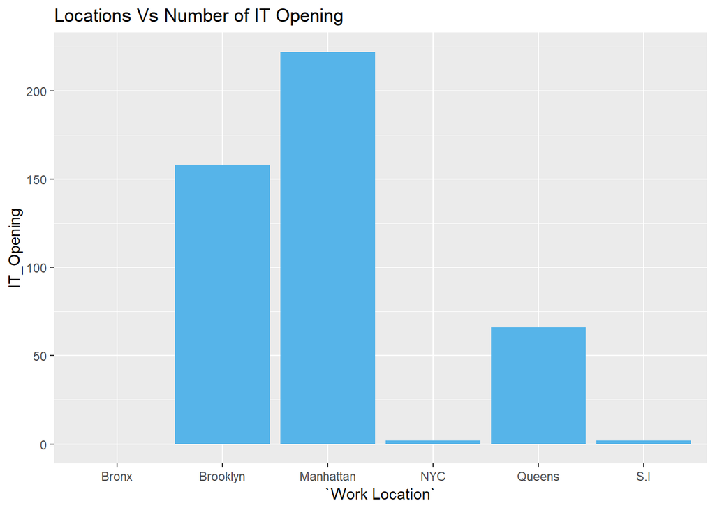

```r
ggplot(data=IT_Location, aes(x=`Work Location`, y=IT_Opening)) +
    geom_bar(stat="identity", position=position_dodge(),fill="#56B4E9")+
    labs(title="Locations Vs Number of IT Opening")
```

Above graph shows the relationship between Work Location and IT Job Openings.

```r
NonIT_Location = nyc_data %>% group_by(`Work Location`) %>% summarize(NonIT_Opening = sum(Non_IT))
NonIT_Location
```

```
## # A tibble: 6 x 2
##   `Work Location` NonIT_Opening
##   <chr>                   <int>
## 1 Bronx                      56
## 2 Brooklyn                  174
## 3 Manhattan                1504
## 4 NYC                       187
## 5 Queens                   1254
## 6 S.I                        43
```

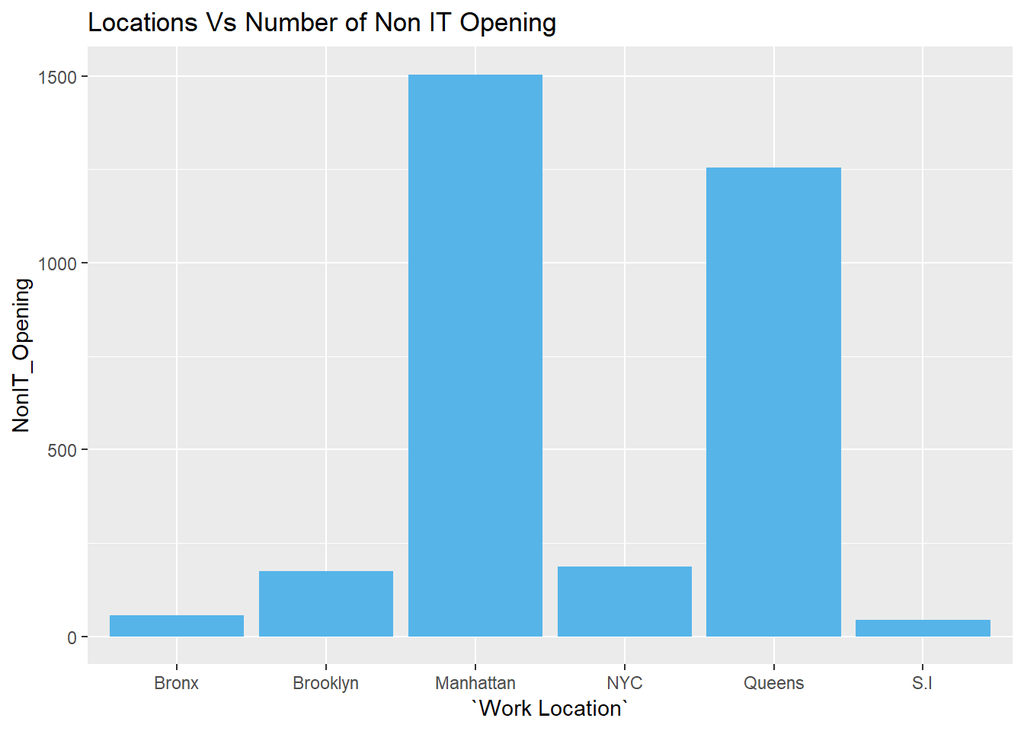

```r
ggplot(data=NonIT_Location, aes(x=`Work Location`, y=NonIT_Opening)) +
    geom_bar(stat="identity", position=position_dodge(),fill="#56B4E9")+
    labs(title="Locations Vs Number of Non IT Opening")
```

Above graph shows the relationship between Work Location and Non-IT Job Openings.

In NYC, there are maximum non-IT Job Openings in Manhattan around 1500. After Manhattan, in Queens, there are Non-IT Job Openings around 1250. Whereas in S.I(Staten Island), there is almost no job opening in Non-IT.

2. What is the average maximum and minimum annual and hourly salary in each locations.

#### Ans.2

```r
df2 = rename(nyc_data ,AvgMinAnnualSalary = Annual_salary_from, AvgMaxAnnualSalary= Annual_Salary_to, AvgMinHourlySalary = Hourly_Salary_from , AvgMaxHourlySalary = Hourly_Salary_to)

dd = df2 %>% group_by(`Work Location`) %>% summarise(AvgMinAnnualSalary = round(mean(AvgMinAnnualSalary)), AvgMaxAnnualSalary=round(mean(AvgMaxAnnualSalary)), AvgMinHourlySalary = round(mean(AvgMinHourlySalary)) , AvgMaxHourlySalary=round(mean(AvgMaxHourlySalary)))

dd
```

```
## # A tibble: 6 x 5
##   `Work Location` AvgMinAnnualSal~ AvgMaxAnnualSal~ AvgMinHourlySal~
##   <chr>                      <dbl>            <dbl>            <dbl>
## 1 Bronx                      46299            58239                6
## 2 Brooklyn                   51360            69114                6
## 3 Manhattan                  59354            84439                5
## 4 NYC                        64532           103325                4
## 5 Queens                     51034            70615               10
## 6 S.I                        58266            77464                5
## # ... with 1 more variable: AvgMaxHourlySalary <dbl>
```

EXPLANATION - The above analysis result shows the average minimum and miximum salary in all the locations. The maximum and minimum average salary is annually and hourly based. This means that our analysis collect all the minimum and maximum salaries location wise and then calculates the average of all to give the results.

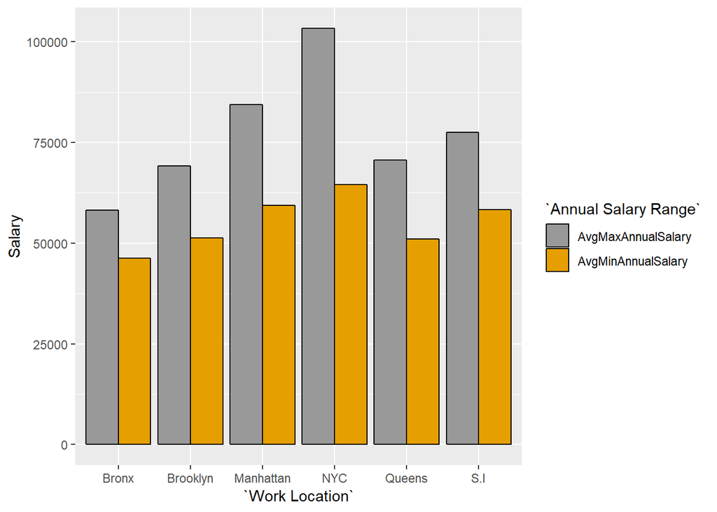

```r
dd3 =gather(dd, 'Annual Salary Range', Salary, 2:3)
ggplot(data=dd3, aes(x=`Work Location`, y=Salary, fill=`Annual Salary Range`)) +
    geom_bar(stat="identity", position=position_dodge(), colour="black") +
    scale_fill_manual(values=c("#999999", "#E69F00"))
```

EXPLANATION -The above plot shows the Annual average maximum and minimum salary on all locations. The average maximum salary is in NYC and least maximum salary is in Bronx. The highest average minimum annual salary is in NYC and least average minimum is at Bronx.

```r
hourly =gather(dd, 'Hourly Salary Range', Salary, 4:5)

hourly
```

```
## # A tibble: 12 x 5
##    `Work Location` AvgMinAnnualSal~ AvgMaxAnnualSal~ `Hourly Salary ~
##    <chr>                      <dbl>            <dbl> <chr>
##  1 Bronx                      46299            58239 AvgMinHourlySal~
##  2 Brooklyn                   51360            69114 AvgMinHourlySal~
##  3 Manhattan                  59354            84439 AvgMinHourlySal~
##  4 NYC                        64532           103325 AvgMinHourlySal~
##  5 Queens                     51034            70615 AvgMinHourlySal~
##  6 S.I                        58266            77464 AvgMinHourlySal~
##  7 Bronx                      46299            58239 AvgMaxHourlySal~
##  8 Brooklyn                   51360            69114 AvgMaxHourlySal~
##  9 Manhattan                  59354            84439 AvgMaxHourlySal~
## 10 NYC                        64532           103325 AvgMaxHourlySal~
## 11 Queens                     51034            70615 AvgMaxHourlySal~
## 12 S.I                        58266            77464 AvgMaxHourlySal~
## # ... with 1 more variable: Salary <dbl>
```

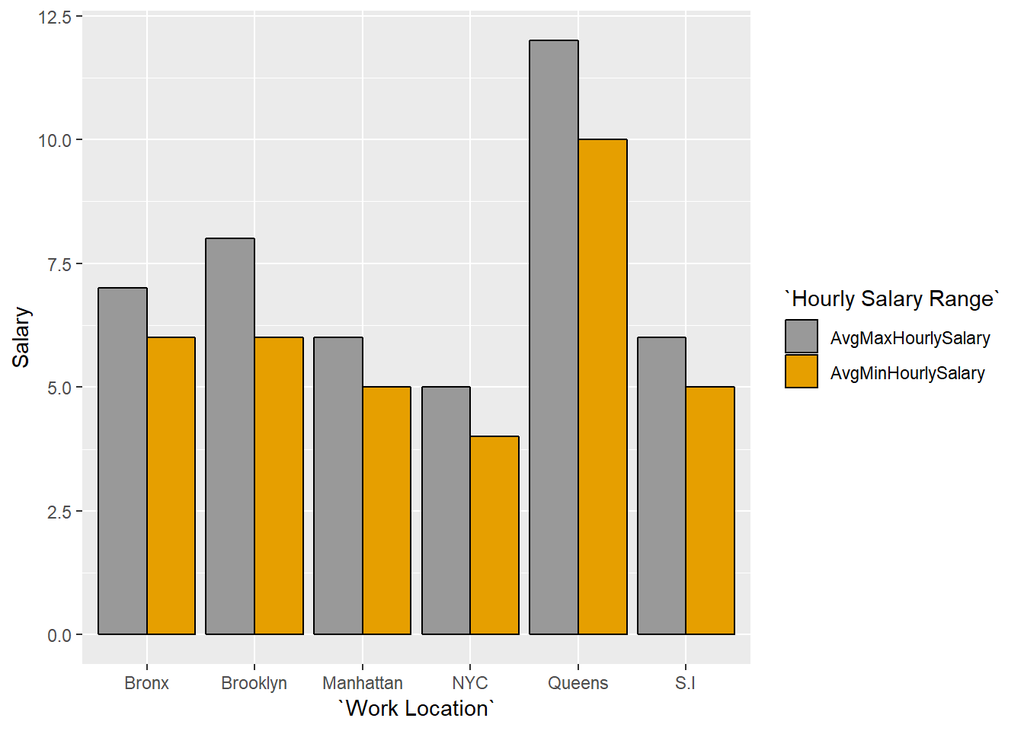

```r
ggplot(data=hourly, aes(x=`Work Location`, y=Salary, fill=`Hourly Salary Range`)) +
    geom_bar(stat="identity", position=position_dodge(), colour="black") +
    scale_fill_manual(values=c("#999999", "#E69F00"))
```

EXPLANATION -The above plot shows that average maximum and minimum hourly salary on all locations. The average maximum salary is in Queens and least maximum salary is in NYC. The highest average minimum hourly salary is in Queens and least average minimum is at NYC.

3. How many part-time and full time jobs are there in each location.

#### Ans.3

```r
df3<- nyc_data %>% group_by(`Work Location`) %>% summarise(Part_Time = sum(Part_Time), Full_Time=sum(Full_Time))
df3
```

```
## # A tibble: 6 x 3
##   `Work Location` Part_Time Full_Time
##   <chr>               <int>     <int>
## 1 Bronx                  46        10
## 2 Brooklyn              261        69
## 3 Manhattan            1564       162
## 4 NYC                   155        34
## 5 Queens               1134       188
## 6 S.I                    43         2
```

```r
df4=gather(df3,F_T_Time,F_T_number,2:3)
df4
```

```
## # A tibble: 12 x 3
##    `Work Location` F_T_Time  F_T_number
##    <chr>           <chr>          <int>
##  1 Bronx           Part_Time         46
##  2 Brooklyn        Part_Time        261
##  3 Manhattan       Part_Time       1564
##  4 NYC             Part_Time        155
##  5 Queens          Part_Time       1134
##  6 S.I             Part_Time         43
##  7 Bronx           Full_Time         10
##  8 Brooklyn        Full_Time         69
##  9 Manhattan       Full_Time        162
## 10 NYC             Full_Time         34
## 11 Queens          Full_Time        188
## 12 S.I             Full_Time          2
```

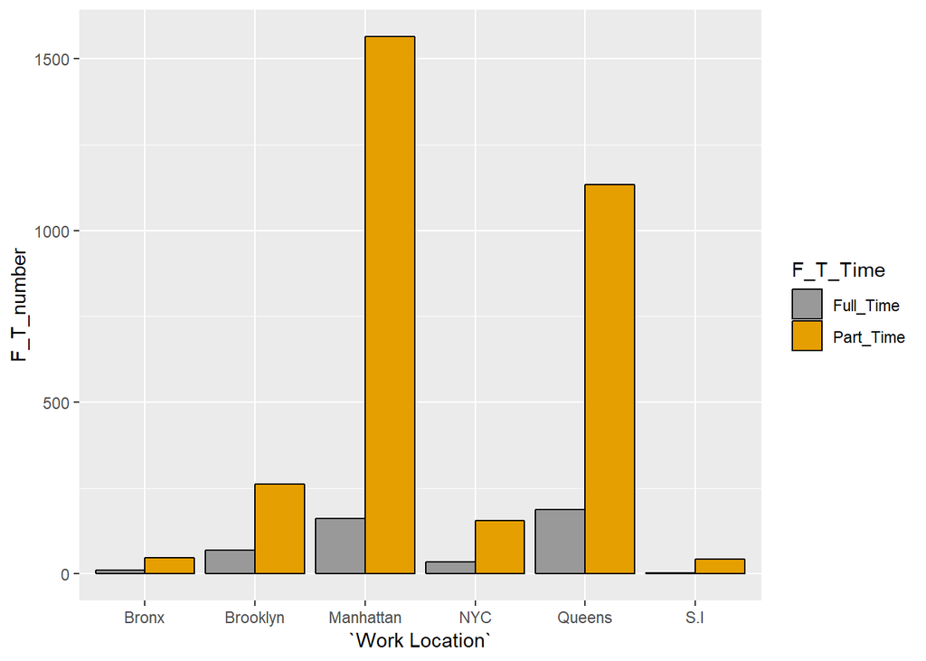

```r
ggplot(data=df4, aes(x=`Work Location`, y=F_T_number, fill=F_T_Time)) +
    geom_bar(stat="identity", position=position_dodge(), colour="black") +
    scale_fill_manual(values=c("#999999", "#E69F00"))
```

Explaination— The above result describes that ‘Manhattan’ has the maximum number of Part_Time jobs =1564, where as S.I. has the lowest number of Part_Time jobs=43. On the other hand, Queens has the maximum number of Full_Time jobs=188 , whereas S.I again as the lowest number of Full_Time jobs= 2. The ranking for Part_Time would be - Manhattan,Queens,Brooklyn,NYC,Bronx,S.I. The ranking for Full_Time would be - Queens,Manhattan,Brooklyn,NYC,Bronx,S.I.

4. Relashionship between salary frequency based on location. Which Work Location has the most jobs opening provided with Annual Salary/Daily Salary/Hourly. Salary?

#### Ans.4

1.Locations Vs AnnualSalaryFreq

```r
jobannual <- aggregate(nyc_data$Annual_Salary_freq, by=list(nyc_data$`Work Location`), FUN=sum)
jobannual
```

```
##     Group.1    x
## 1     Bronx   43
## 2  Brooklyn  305
## 3 Manhattan 1592
## 4       NYC  151
## 5    Queens 1215
## 6       S.I   41
```

```r
colnames(jobannual) <- c("Locations", "AnnualSalaryFreq")
jobannual <- jobannual[order(jobannual$AnnualSalaryFreq), ]
jobannual$Locations <- factor(jobannual$Locations, levels = jobannual$Locations)
head(jobannual,8)
```

```
##   Locations AnnualSalaryFreq
## 6       S.I               41
## 1     Bronx               43
## 4       NYC              151
## 2  Brooklyn              305
## 5    Queens             1215
## 3 Manhattan             1592
```

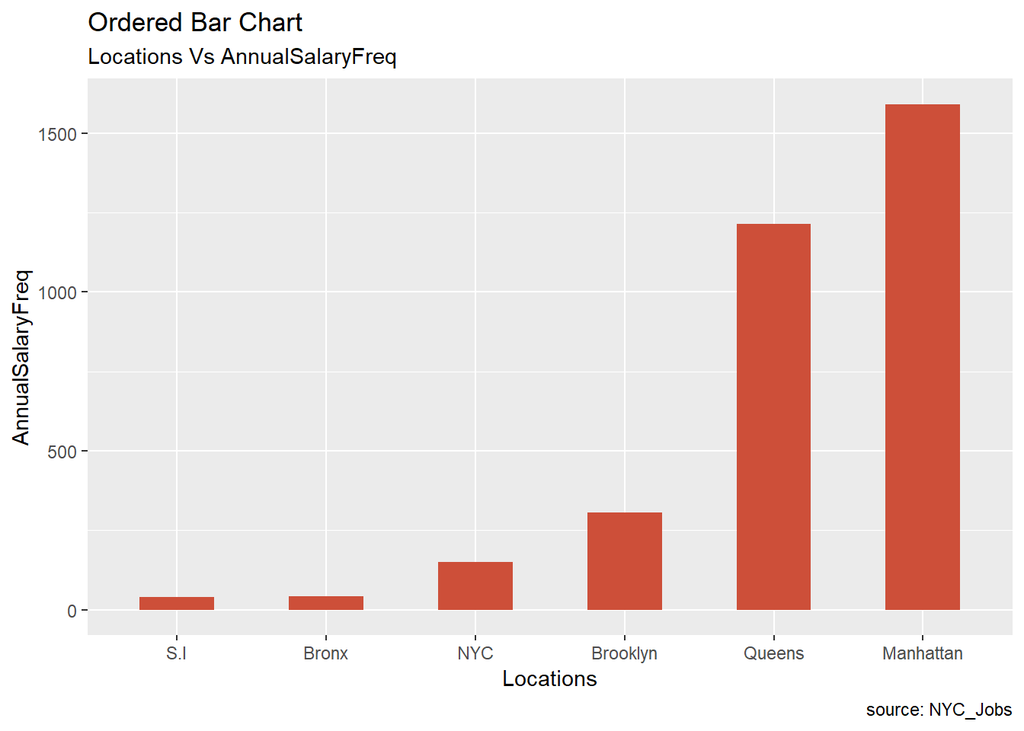

```r
# Draw plot
ggplot(jobannual, aes(x=Locations, y=AnnualSalaryFreq)) + geom_bar(stat="identity", width=.5, fill="tomato3") + labs(title="Ordered Bar Chart",subtitle="Locations Vs AnnualSalaryFreq", caption="source: NYC_Jobs")
```

From the above graph âLocations Vs AnnualSalaryFreqâ, it can be seen that *Manhattan has the most jobs opening, total of 1592, provide with annual salary.* The ranking will be: Manhattan, Queens, Brooklyn, Bronx, Staten Island.

2.Locations Vs DailySalaryFreq

```r
jobdaily <- aggregate(nyc_data$Daily_salary_freq, by=list(nyc_data$`Work Location`), FUN=sum)
colnames(jobdaily) <- c("Locations", "DailySalaryFreq")
jobdaily <- jobdaily[order(jobdaily$DailySalaryFreq), ]
jobdaily$Locations <- factor(jobdaily$Locations, levels = jobdaily$Locations)
head(jobdaily,8)
```

```
##   Locations DailySalaryFreq
## 6       S.I               0
## 2  Brooklyn               2
## 1     Bronx               3
## 4       NYC               6
## 3 Manhattan              12
## 5    Queens              13
```

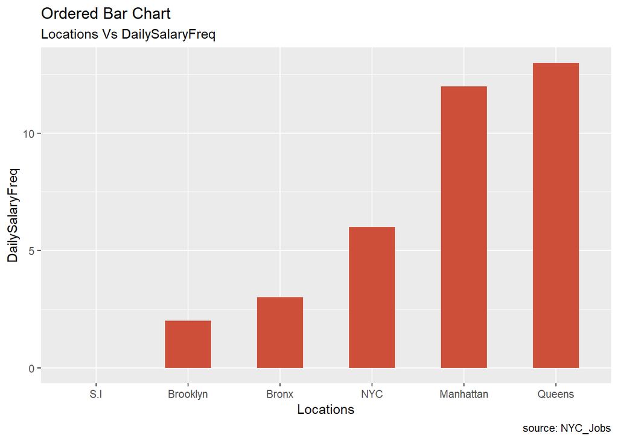

```r
ggplot(jobdaily, aes(x=Locations, y=DailySalaryFreq)) + geom_bar(stat="identity", width=.5, fill="tomato3") + labs(title="Ordered Bar Chart",subtitle="Locations Vs DailySalaryFreq", caption="source: NYC_Jobs")
```

3.Locations Vs HourlySalaryFreq

```r
jobhourly <- aggregate(nyc_data$Hourly_salary_freq, by=list(nyc_data$`Work Location`), FUN=sum)
colnames(jobhourly) <- c("Locations", "HourlySalaryFreq")
jobhourly <- jobhourly[order(jobhourly$HourlySalaryFreq), ]
jobhourly$Locations <- factor(jobhourly$Locations, levels = jobhourly$Locations)
head(jobhourly,8)
```

```
##   Locations HourlySalaryFreq
## 6       S.I                4
## 1     Bronx               10
## 2  Brooklyn               25
## 4       NYC               32
## 5    Queens               94
## 3 Manhattan              127
```

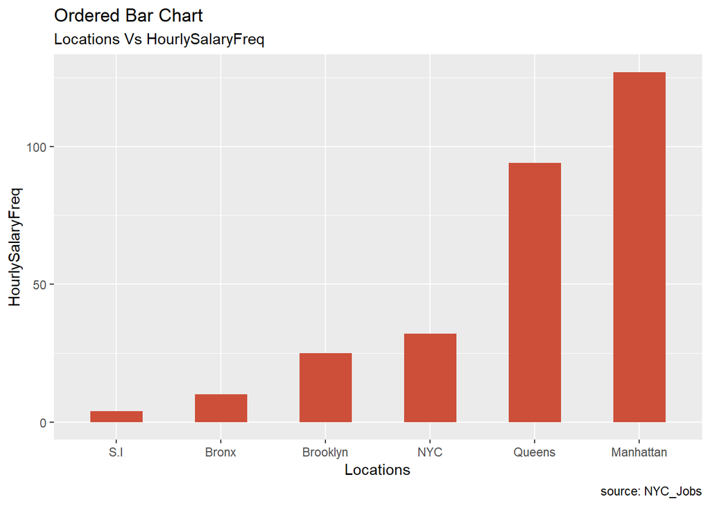

```r
ggplot(jobhourly, aes(x=Locations, y=HourlySalaryFreq)) + geom_bar(stat="identity", width=.5, fill="tomato3") + labs(title="Ordered Bar Chart",subtitle="Locations Vs HourlySalaryFreq", caption="source: NYC_Jobs")
```

From the above graph âLocations Vs HourlySalaryFreqâ, it can be seen that *Manhattan has the most jobs opening, total of 127, provide with Hourly salary. And there are only 4 jobs opening provide with hourly salary in Staten Island.* The ranking will be: Manhattan, Queens, Brooklyn, Bronx, Staten Island.

Observation From the above result it is seen that Manhattan has the most jobs opening on both Anuuanl and Hourly salary. Queens has the most jobs opening for Daily Salary and has the second most jobs opening with Annual and Hourly salary. Staten Island has the least number of jobs opening on all anuual, daliy, and hourly salary.

### Conclusion

We worked on the dataset NYC_Jobs. After going through all the variables and details of the project and dataset we analysed all the available material and tried simplifying it as much as possible to make it understandable. We explored most of the variables which were relevant to our analysis. After dividing the job categories into IT and Non-IT fields we used the variables in relevance to the jobs available. We got to know about what are the salaries paid in 6 boroughs of NYC may it be maximum or minimum. Here are our findings - 1. We got to know the relationship between Work Location and IT and Non IT Job Opening with graph and explaination. 2. We explored the average salary in each locations both maximum and minimum on annual and hourly basis. 3. We analysed jobs based on timings - both part-time and full time location wise. 4. Explored the relashionship between salary frequency based on location. After exploring and analyzing our data, and finding our results, We are still interested in predicting the outcomes related to all possible variables. For example, we can predict the salary range and IT/Non-IT Job Openings based on work locations.